# Vivi_Fitriyani_1306620050_Project_Pengolahan_Citra_Digital

> Nama : Vivi Fitriyani

> NIM : 1306650050

> Projek Pengolahan Citra Digital

### Mengimport Libary

```python
from PIL import Image
from skimage.io import imread, imshow, show
import scipy.fftpack as fp
from scipy import ndimage, misc, signal
from scipy import stats
from skimage import data, img_as_float
from skimage.color import rgb2gray
from skimage.transform import rescale
import matplotlib.pylab as pylab
import matplotlib.pyplot as plt
import cv2
from skimage import data, img_as_float, img_as_ubyte, exposure, io, color
from cv2 import imshow
import numpy as np
import numpy.fft
import timeit
```

### Import Gambar

```python
from google.colab import drive
drive.mount('/content/drive')
```

### Transformasi Fourier

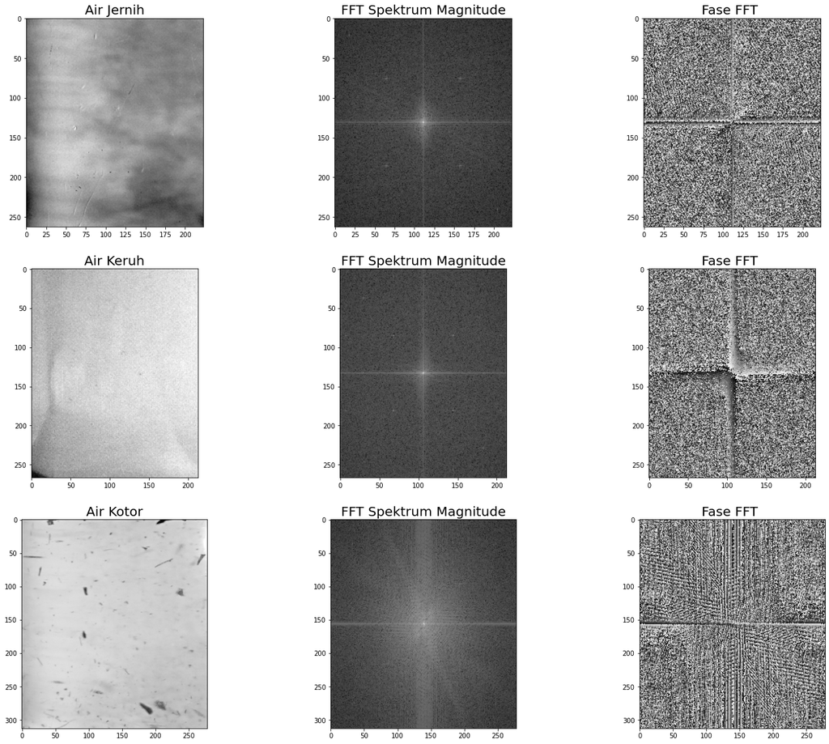

```python
from matplotlib.colors import LogNorm
im_jernih = rgb2gray(imread('/content/drive/MyDrive/PCD/Project PCD/Air_Jenih.png'))
im_keruh = rgb2gray(imread('/content/drive/MyDrive/PCD/Project PCD/Air Keruh.png'))
im_kotor = rgb2gray(imread('/content/drive/MyDrive/PCD/Project PCD/Air_Kotor.png'))
pylab.figure(figsize=(24,20))
freq_jernih = fp.fft2(im_jernih)
freq_keruh = fp.fft2(im_keruh)
freq_kotor = fp.fft2(im_kotor)
im2_jernih = fp.ifft2(freq_jernih).real
im2_keruh = fp.ifft2(freq_keruh).real
im2_kotor = fp.ifft2(freq_kotor).real
pylab.subplot(3,3,1), pylab.imshow(im_jernih, cmap='gray'), pylab.title('Air Jernih', size=20)
pylab.subplot(3,3,2), pylab.imshow(20*np.log10( 0.01 + np.abs(fp.fftshift(freq_jernih))), cmap='gray'),pylab.title('FFT Spektrum Magnitude', size=20)
pylab.subplot(3,3,3), pylab.imshow(np.angle(fp.fftshift(freq_jernih)),cmap='gray'), pylab.title('Fase FFT ', size=20)
pylab.subplot(3,3,4), pylab.imshow(im_keruh, cmap='gray'), pylab.title('Air Keruh', size=20)
pylab.subplot(3,3,5), pylab.imshow(20*np.log10( 0.01 + np.abs(fp.fftshift(freq_keruh))), cmap='gray'), pylab.title('FFT Spektrum Magnitude', size=20)
pylab.subplot(3,3,6), pylab.imshow(np.angle(fp.fftshift(freq_keruh)),cmap='gray'), pylab.title('Fase FFT ', size=20)
pylab.subplot(3,3,7), pylab.imshow(im_kotor, cmap='gray'), pylab.title('Air Kotor', size=20)
pylab.subplot(3,3,8), pylab.imshow(20*np.log10( 0.01 + np.abs(fp.fftshift(freq_kotor))), cmap='gray'), pylab.title('FFT Spektrum Magnitude', size=20)
pylab.subplot(3,3,9), pylab.imshow(np.angle(fp.fftshift(freq_kotor)),cmap='gray'), pylab.title('Fase FFT ', size=20)
pylab.savefig('FFT AIR')
```

Pertama-tama, transformasi ke domain frekuensi menghasilkan pemahaman gambar yang lebih baik. Seperti yang akan kita lihat di beberapa bagian berikutnya, frekuensi rendah dalam domain frekuensi sesuai dengan rata-rata tingkat kotor informasi dalam gambar, sedangkan frekuensi yang lebih tinggi sesuai dengan tepi, derau, dan informasi yang lebih detail. dan dapat dilihat gambar diatas bahwa pada air kotor terdapat derau hal tersebut terjadi karena dalam air kotor terdapat benda asing yang dapat diartikan adanya noise dibandingkan pada air keruh dan jernih

### Histogram RGB

```python
def plot_image(image, title=''):
 pylab.title(title, size=20), pylab.imshow(image)
 pylab.axis('off') # comment this line if you want axis ticks
def plot_hist(r, g, b, title=''):
 r, g, b = img_as_ubyte(r), img_as_ubyte(g), img_as_ubyte(b)
 pylab.hist(np.array(r).ravel(), bins=256, range=(0, 256), color='r',
alpha=0.5)
 pylab.hist(np.array(g).ravel(), bins=256, range=(0, 256), color='g',
alpha=0.5)
 pylab.hist(np.array(b).ravel(), bins=256, range=(0, 256), color='b',
alpha=0.5)
 pylab.xlabel('pixel value', size=20), pylab.ylabel('frequency',
size=20)
 pylab.title(title, size=20)
```

```python
# Import Module
from PIL import Image

def most_common_used_color(img):
	# Get width and height of Image
	width, height = img.size

	# Initialize Variable
	r_total = 0
	g_total = 0
	b_total = 0

	count = 0

	# Iterate through each pixel
	for x in range(0, width):
		for y in range(0, height):
			# r,g,b value of pixel
			r, g, b = img.getpixel((x, y))

			r_total += r
			g_total += g
			b_total += b
			count += 1

	return (r_total/count, g_total/count, b_total/count)
```

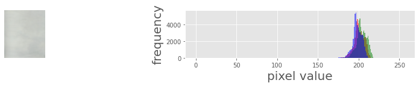

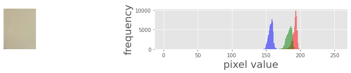

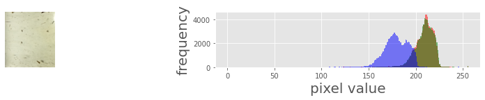

```python
im_jernih = Image.open('/content/drive/MyDrive/PCD/Project PCD/Air_Jenih.png')
im_keruh = Image.open('/content/drive/MyDrive/PCD/Project PCD/Air Keruh.png')
im_kotor = Image.open('/content/drive/MyDrive/PCD/Project PCD/Air_Kotor.png')
im_r, im_g, im_b, _ = im_jernih.split()
pylab.style.use('ggplot'),pylab.figure(figsize=(15,5)),pylab.subplot(321),plot_image(im_jernih)
pylab.subplot(322), plot_hist(im_r, im_g, im_b)
im_r, im_g, im_b, _ = im_keruh.split()
pylab.style.use('ggplot'), pylab.figure(figsize=(15,5)), pylab.subplot(323),plot_image(im_keruh)
pylab.subplot(324),plot_hist(im_r, im_g, im_b)
im_r, im_g, im_b, _ = im_kotor.split()
pylab.style.use('ggplot'), pylab.figure(figsize=(15,5)), pylab.subplot(325),plot_image(im_kotor)
pylab.subplot(326),plot_hist(im_r, im_g, im_b)
pylab.savefig('Hostogram AIR')
```

```python
im_jernih = im_jernih.convert('RGB')
im_keruh = im_keruh.convert('RGB')
im_kotor = im_kotor.convert('RGB')
RGB_jernih = most_common_used_color(im_jernih)
print('Nilai RGB Air Jernih :', RGB_jernih)
RGB_keruh = most_common_used_color(im_keruh)
print('Nilai RGB Air keruh :', RGB_keruh)
RGB_kotor = most_common_used_color(im_kotor)
print('Nilai RGB Air kotor :', RGB_kotor)
```

```
Nilai RGB Air Jernih : (200.18503299288992, 203.41340858326654, 197.9992838752579)
Nilai RGB Air keruh : (191.28916319389495, 183.08280142779273, 156.1950027254664)
Nilai RGB Air kotor : (207.93763072609005, 207.81920150780334, 178.0672075757924)
```

hasil nilai RGB pada air jernih memiliki kemiripan antara satu dengan lainnya hal itu terjadi karena warna pada air jernih tersamarkan dengan background yang digunakan yaitu berwarna putih yang mana apabila RGB digabungkan akan menjadi putih. hasil nilai RGB pada air keruh memiliki kecenderuman percampuran warna merah dan hijau hal tersebut sesuai dengan gambar dari air keruh yang memiliki kecenderungan kearah warna kuning. begitupun dengan air kotor yang memiliki dominan nilai merah dan hijau lebih besar karena didalamnya terdapat warna yang lebih pekat.

### Histogram Equalization

```python
import matplotlib
matplotlib.rcParams['font.size'] = 8
def plot_image_and_hist(image, axes, bins=256):
 image = img_as_float(image)
 axes_image, axes_hist = axes
 axes_cdf = axes_hist.twinx()
 axes_image.imshow(image, cmap=pylab.cm.gray)
 axes_image.set_axis_off()
 axes_hist.hist(image.ravel(), bins=bins, histtype='step',color='black')
 axes_hist.set_xlim(0, 1)
 axes_hist.set_xlabel('Pixel intensity', size=15)
 axes_hist.ticklabel_format(axis='y', style='scientific', scilimits=(0,0))
 axes_hist.set_yticks([])
 image_cdf, bins = exposure.cumulative_distribution(image, bins)
 axes_cdf.plot(bins, image_cdf, 'r')
 axes_cdf.set_yticks([])
 return axes_image, axes_hist, axes_cdf
```

[output not shown]

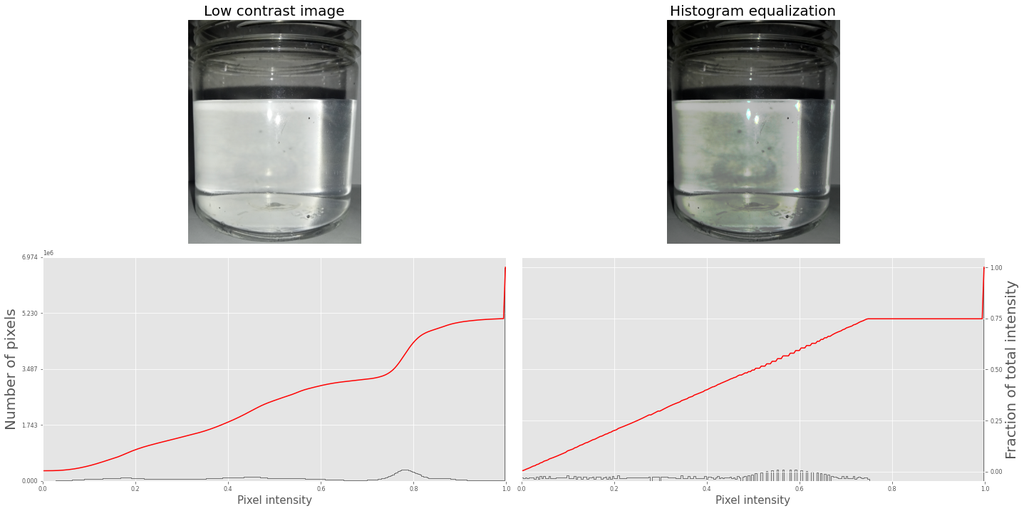

```python
im = io.imread('/content/drive/MyDrive/PCD/Project PCD/Air_Jernih_Gelas.png')
# contrast stretching
im_rescale = exposure.rescale_intensity(im, in_range=(0, 100),out_range=(0, 255))
im_eq = exposure.equalize_hist(im) # histogram equalization
im_adapteq = exposure.equalize_adapthist(im, clip_limit=0.03) # adaptivehistogram equalization
fig = pylab.figure(figsize=(20, 10))
axes = np.zeros((2, 4), dtype = np.object)
axes[0, 0] = fig.add_subplot(2, 2, 1)
for i in range(1, 2):
 axes[0, i] = fig.add_subplot(2, 2, 1+i, sharex=axes[0,0],sharey=axes[0,0])
for i in range(0, 2):
 axes[1, i] = fig.add_subplot(2, 2, 3+i)
axes_image, axes_hist, axes_cdf = plot_image_and_hist(im, axes[:, 0])
axes_image.set_title('Low contrast image', size=20)
y_min, y_max = axes_hist.get_ylim()
axes_hist.set_ylabel('Number of pixels', size=20)
axes_hist.set_yticks(np.linspace(0, y_max, 5))
#axes_image, axes_hist, axes_cdf = plot_image_and_hist(im_adapteq,axes[:,1])
#axes_image.set_title('Adaptive equalizatio', size=20)
axes_image, axes_hist, axes_cdf = plot_image_and_hist(im_eq, axes[:, 1])
axes_image.set_title('Histogram equalization', size=20)
axes_cdf.set_ylabel('Fraction of total intensity', size=20)
axes_cdf.set_yticks(np.linspace(0, 1, 5))
fig.tight_layout()
pylab.show()
```

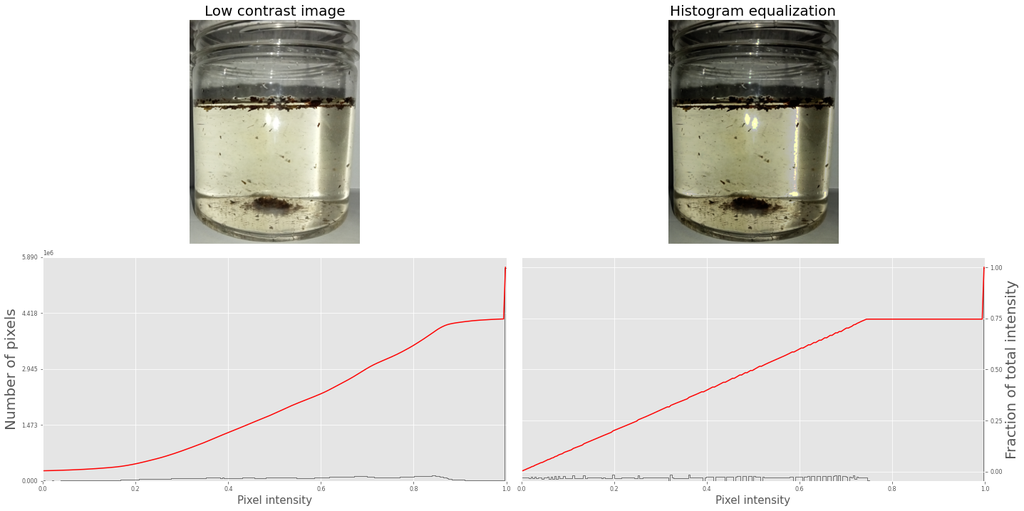

```python
im = io.imread('/content/drive/MyDrive/PCD/Project PCD/Air_Kotor_Gelas.png')
im_rescale = exposure.rescale_intensity(im, in_range=(0, 100),out_range=(0, 255))
im_eq = exposure.equalize_hist(im) # histogram equalization
im_adapteq = exposure.equalize_adapthist(im, clip_limit=0.03) # adaptivehistogram equalization
fig = pylab.figure(figsize=(20, 10))
axes = np.zeros((2, 4), dtype = np.object)
axes[0, 0] = fig.add_subplot(2, 2, 1)
for i in range(1, 2):
 axes[0, i] = fig.add_subplot(2, 2, 1+i, sharex=axes[0,0],sharey=axes[0,0])
for i in range(0, 2):
 axes[1, i] = fig.add_subplot(2, 2, 3+i)
axes_image, axes_hist, axes_cdf = plot_image_and_hist(im, axes[:, 0])
axes_image.set_title('Low contrast image', size=20)
y_min, y_max = axes_hist.get_ylim()
axes_hist.set_ylabel('Number of pixels', size=20)
axes_hist.set_yticks(np.linspace(0, y_max, 5))
#axes_image, axes_hist, axes_cdf = plot_image_and_hist(im_adapteq,axes[:,1])
#axes_image.set_title('Adaptive equalizatio', size=20)
axes_image, axes_hist, axes_cdf = plot_image_and_hist(im_eq, axes[:, 1])
axes_image.set_title('Histogram equalization', size=20)
axes_cdf.set_ylabel('Fraction of total intensity', size=20)
axes_cdf.set_yticks(np.linspace(0, 1, 5))
fig.tight_layout()
pylab.show()
```

[output not shown]

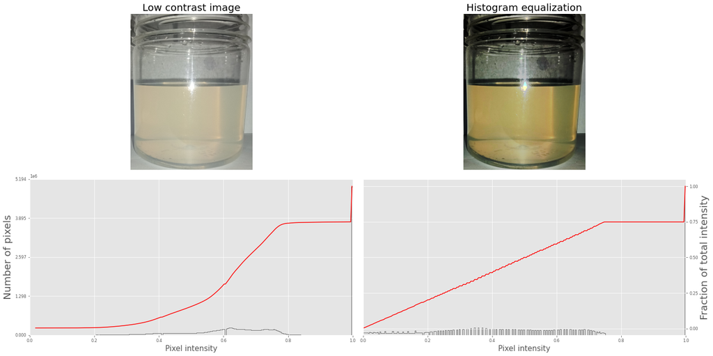

```python
im = io.imread('/content/drive/MyDrive/PCD/Project PCD/Air_Keruh_Gelas.png')
im_rescale = exposure.rescale_intensity(im, in_range=(0, 100),out_range=(0, 255))
im_eq = exposure.equalize_hist(im) # histogram equalization
im_adapteq = exposure.equalize_adapthist(im, clip_limit=0.03) # adaptivehistogram equalization
fig = pylab.figure(figsize=(20, 10))
axes = np.zeros((2, 4), dtype = np.object)
axes[0, 0] = fig.add_subplot(2, 2, 1)
for i in range(1, 2):
 axes[0, i] = fig.add_subplot(2, 2, 1+i, sharex=axes[0,0],sharey=axes[0,0])
for i in range(0, 2):
 axes[1, i] = fig.add_subplot(2, 2, 3+i)
axes_image, axes_hist, axes_cdf = plot_image_and_hist(im, axes[:, 0])
axes_image.set_title('Low contrast image', size=20)
y_min, y_max = axes_hist.get_ylim()
axes_hist.set_ylabel('Number of pixels', size=20)
axes_hist.set_yticks(np.linspace(0, y_max, 5))
#axes_image, axes_hist, axes_cdf = plot_image_and_hist(im_adapteq,axes[:,1])
#axes_image.set_title('Adaptive equalizatio', size=20)
axes_image, axes_hist, axes_cdf = plot_image_and_hist(im_eq, axes[:, 1])
axes_image.set_title('Histogram equalization', size=20)
axes_cdf.set_ylabel('Fraction of total intensity', size=20)
axes_cdf.set_yticks(np.linspace(0, 1, 5))
fig.tight_layout()
pylab.show()
```

histogram equalization dapat digunakan untuk melakukan perbaikan terhadap gambar. hal berdasarkan percobaan diatas hal tersebut tampak cocok digunakan untuk menganalisi air dengan kotoran karena gambar akan dibuat lebih jelas, sedangkan untuk air keruh tidak pas karena warna yang dibuat akan berubah

### Threshold

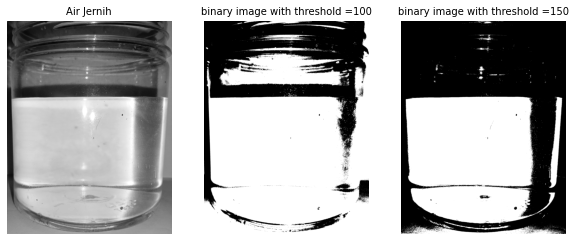

```python
im_jernih = Image.open('/content/drive/MyDrive/PCD/Project PCD/Air_Jernih_Gelas.png').convert('L')
im_keruh = Image.open('/content/drive/MyDrive/PCD/Project PCD/Air_Keruh_Gelas.png').convert('L')
im_kotor = Image.open('/content/drive/MyDrive/PCD/Project PCD/Air_Kotor_Gelas.png').convert('L')
def plot_image(image, title=''):
 pylab.title(title, size=10), pylab.imshow(image)
 pylab.axis('off') # comment this line if you want axis ticks

pylab.figure(figsize=(10,7))
pylab.gray()
pylab.subplot(131), plot_image(im_jernih, 'Air Jernih'), pylab.axis('off')
th = [0, 70, 100, 150]
for i in range(2, 4):
 im1 = im_jernih.point(lambda x: x > th[i])
 pylab.subplot(1,3,i), plot_image(im1, 'binary image with threshold =' +str(th[i]))
```

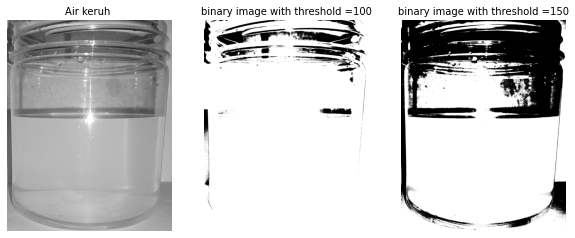

```python
pylab.figure(figsize=(10,7))
pylab.gray()
pylab.subplot(131), plot_image(im_keruh, 'Air keruh '), pylab.axis('off')
th = [0, 70, 100, 150]
for i in range(2, 4):
 im1 = im_keruh.point(lambda x: x > th[i])
 pylab.subplot(1,3,i), plot_image(im1, 'binary image with threshold =' +str(th[i]))
```

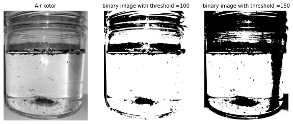

```python
pylab.figure(figsize=(10,7))
pylab.gray()
pylab.subplot(131), plot_image(im_kotor, 'Air kotor'), pylab.axis('off')
th = [0, 70, 100, 150]
for i in range(2, 4):
 im1 = im_kotor.point(lambda x: x > th[i])
 pylab.subplot(1,3,i), plot_image(im1, 'binary image with threshold =' +str(th[i]))
```

pada treshold ini dapat dilihat terjadi perbedaan antara air jernih dan keruh hal tersebut dapat saja terjadi karena pada pengambilan gambar menggunakan cahaya pengisi yang mana sesuai dengan sifat cahaya apabila pada air bening maka cahaya akan diteruskan sedangkan pada air keruh cahaya akan dihamburkan, sehingga dapat dilihat terdapat perbedaan dari gambar diatas. pada air kotor dapat terlihat dengan jelas kotoran yang menumpuk hingga pada cairan.

## Kesimpulan

Berdasarkan hasil analisis diatas terdapat perbedaan antara cara yang dapat digunakan untuk melakukan pengolahan citra digital :

> Apabila ingin melakukan pendeteksi terhadap air kotor dapat menggunakan analisis FFT, Threshold, histogram equalization karena pada analisis tersebut dapat terlihat perbedaanya

> Apabila melakukan analisis terhadap air keruh dapat digunakan analisis RGB dan Threshold karena pada keduanya terdapat perbedaan dengan air jernih sedangkan untuk FFT tidak terlalu nampak begitupun dengan histogram equalization yang merubah warna dari air.